# Homework 1

- Compute and interpret clusters

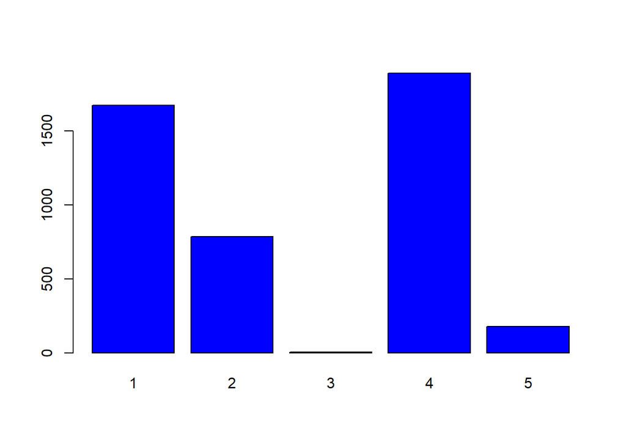

```r
fit = kmeans(dataframe, centers = 5, nstart=100)
groups = fit$cluster

barplot(table(groups), col="blue")
```

The previous barplot shows how the data is distributed through each group. In it, it is clear that the result is not regular, as there are two bigger groups, 1 and 4, and three smaller, 2, 3 and 5, being 3 almost nonexistent.

Once the groups are created, they can be interpreted. First, let’s compute the centers, which are artificial films that represent each group. Taking into account its characteristics, it can be imagined which type of films belong to each group.

```r
centers=fit$centers
centers
```

```
##   data.gross data.duration data.director_facebook_likes
## 1 -0.2622798    -0.5764550                   -0.2176393
## 2  0.8297083     0.3919812                   -0.1666246
## 3 -0.7514589     0.5446581                    0.2772442
## 4 -0.1657100     0.2782530                   -0.1888797
## 5  0.5825048     0.7277493                    4.8088634
##   data.actor_1_facebook_likes data.cast_total_facebook_likes data.budget
## 1                  -0.3608568                     -0.3542423 -0.11495084
## 2                   1.4260388                      1.4595681  0.27924853
## 3                  -0.5734165                     -0.5958216 28.11959143
## 4                  -0.3288896                     -0.3526864 -0.08386371
## 5                   0.6051004                      0.6482579  0.10713229
##   data.imdb_score data.movie_facebook_likes
## 1      -0.9233497                -0.3142314
## 2       0.3989241                 0.7956836
## 3       0.9946111                -0.1858617
## 4       0.5769352                -0.1089208
## 5       0.7782323                 0.6057610
```

To see it better, a graph can be computed.

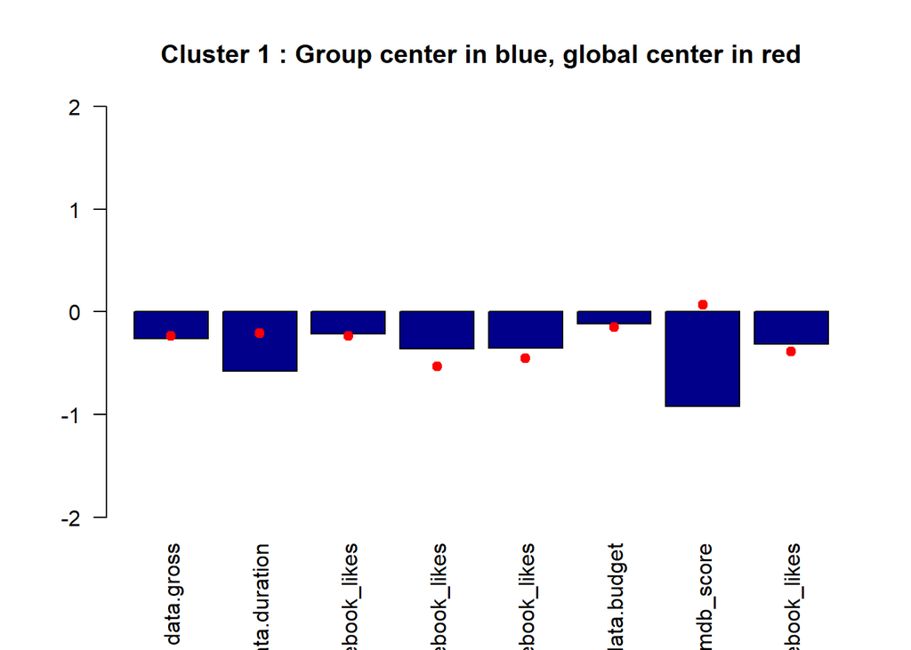

```r
i=1  # plotting the centers in cluster 1
bar1=barplot(centers[i,], las=2, col="darkblue", ylim=c(-2,2), main=paste("Cluster", i,": Group center in blue, global center in red"))
points(bar1,y=apply(dataframe, 2, quantile, 0.50),col="red",pch=19)
```

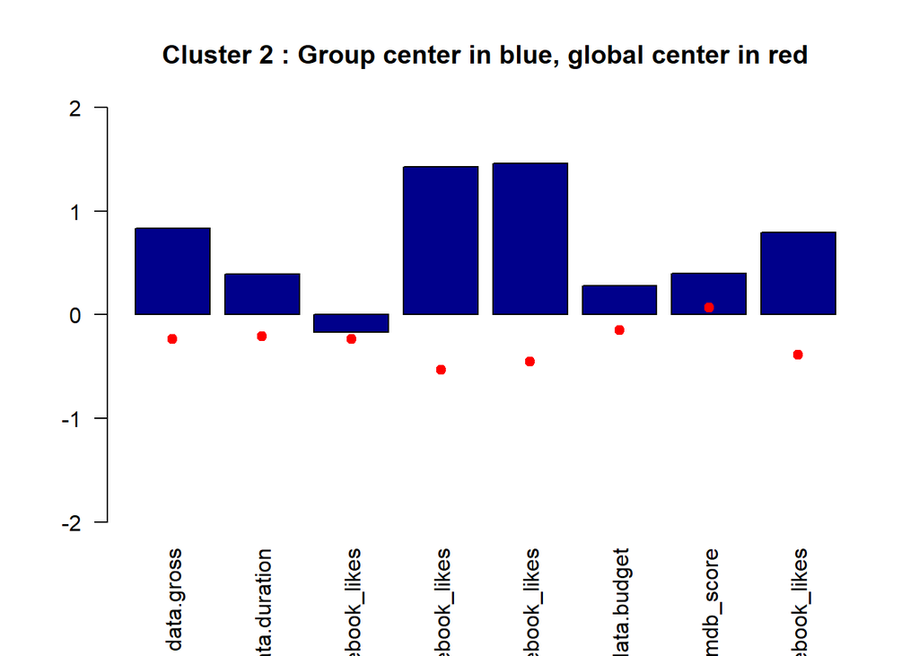

```r
i=2  # plotting the centers in cluster 2
bar2=barplot(centers[i,], las=2, col="darkblue", ylim=c(-2,2), main=paste("Cluster", i,": Group center in blue, global center in red"))
points(bar2,y=apply(dataframe, 2, quantile, 0.50),col="red",pch=19)
```

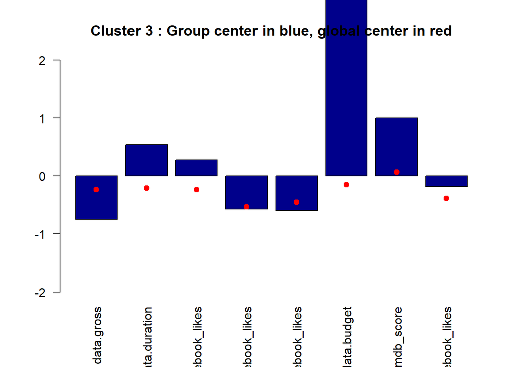

```r
i=3  # plotting the centers in cluster 2
bar2=barplot(centers[i,], las=2, col="darkblue", ylim=c(-2,2), main=paste("Cluster", i,": Group center in blue, global center in red"))
points(bar2,y=apply(dataframe, 2, quantile, 0.50),col="red",pch=19)
```

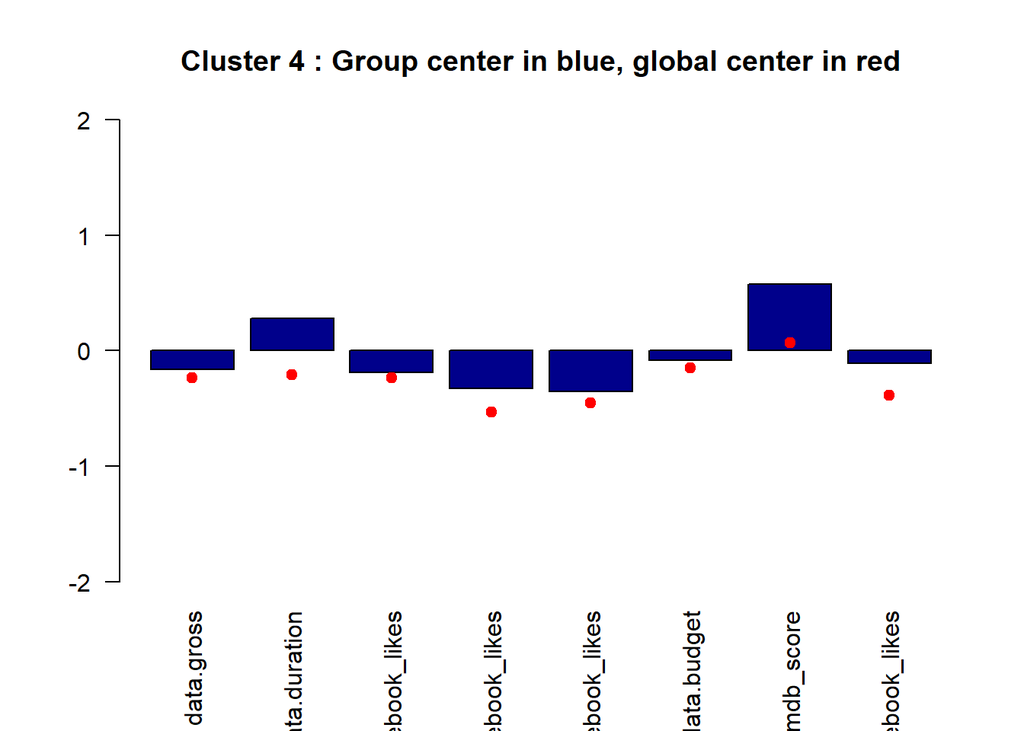

```r
i=4  # plotting the centers in cluster 2
bar2=barplot(centers[i,], las=2, col="darkblue", ylim=c(-2,2), main=paste("Cluster", i,": Group center in blue, global center in red"))
points(bar2,y=apply(dataframe, 2, quantile, 0.50),col="red",pch=19)
```

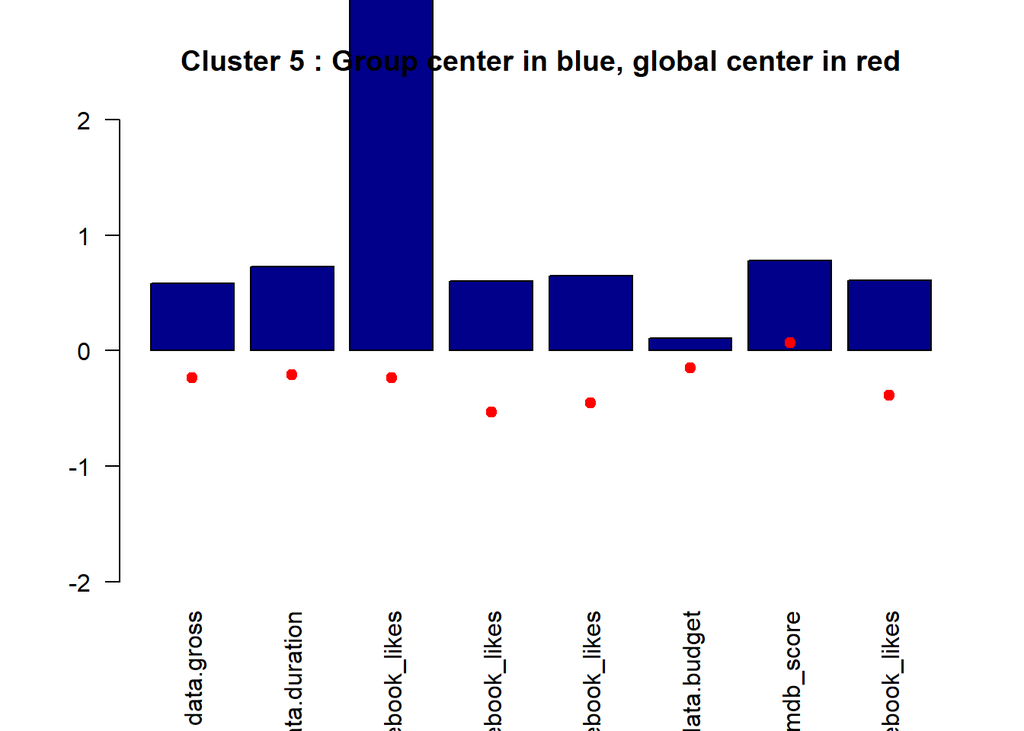

```r
i=5  # plotting the centers in cluster 2
bar2=barplot(centers[i,], las=2, col="darkblue", ylim=c(-2,2), main=paste("Cluster", i,": Group center in blue, global center in red"))
points(bar2,y=apply(dataframe, 2, quantile, 0.50),col="red",pch=19)
```

Regarding cluster 1, it can be seen that it includes unsuccessful movies, as all the values are in negative. Specially, IMDb score is extremely low.

Contrary to cluster 1, cluster 2 includes successful films that, however, have few director likes.

Cluster 3 includes films that were very expensive to create but did not obtain good results.

Cluster 4 includes very average films, that were neither successful nor the contrary.

Finally, cluster 5 includes successful movies, but with very high values in the director Facebook likes.

Now, let’s analyse our principal determinant variables in each cluster.

[figure not shown]

```r
as.data.frame(dataframe) %>% mutate(cluster=factor(groups), data.gross = data.gross, data.actor_1_facebook_likes = data.actor_1_facebook_likes, data.imdb_score = data.imdb_score) %>%
  ggplot(aes(x = cluster, y = data.actor_1_facebook_likes)) +
  geom_boxplot(fill="lightblue") +
  labs(title = "Main actor Facebook likes by cluster", x = "", y = "", col = "")
```

About the actor 1 Facebook likes, 2 has the highest values (5 is close), and 3 the lowest.

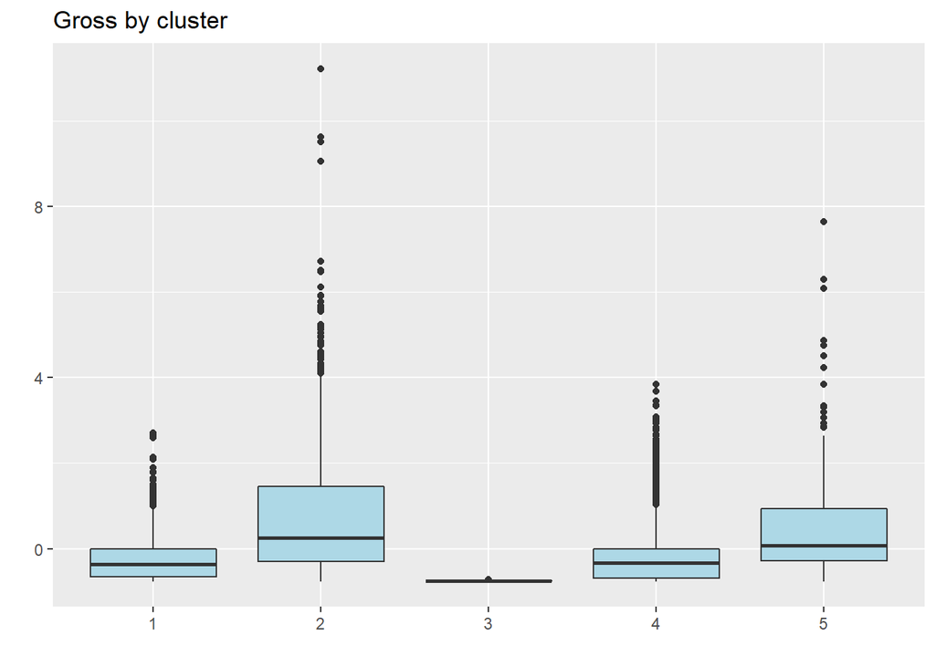

```r
as.data.frame(dataframe) %>% mutate(cluster=factor(groups), data.gross = data.gross, data.actor_1_facebook_likes = data.actor_1_facebook_likes, data.imdb_score = data.imdb_score) %>%
  ggplot(aes(x = cluster, y = data.gross)) +
  geom_boxplot(fill="lightblue") +
  labs(title = "Gross by cluster", x = "", y = "", col = "")
```

About the gross, it can be seen that cluster 2 has the greatest values and 3 the lowest.

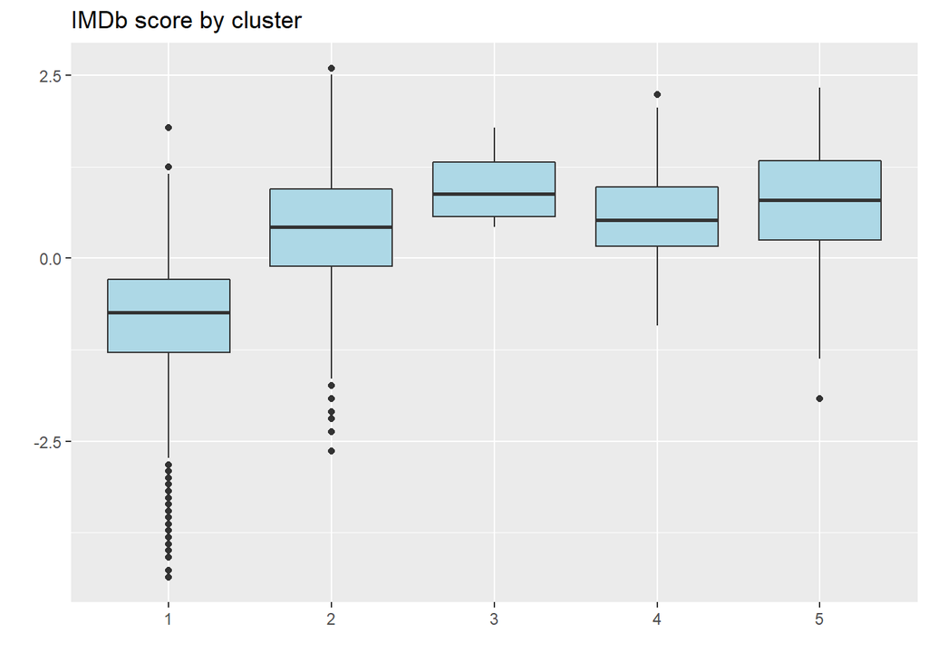

```r
as.data.frame(dataframe) %>% mutate(cluster=factor(groups), data.gross = data.gross, data.actor_1_facebook_likes = data.actor_1_facebook_likes, data.imdb_score = data.imdb_score) %>%
  ggplot(aes(x = cluster, y = data.imdb_score)) +
  geom_boxplot(fill="lightblue") +
  labs(title = "IMDb score by cluster", x = "", y = "", col = "")
```

Finally, about the IMDb score, clusters 3 and 5 have the greatest values, and 1 the lowest.

- Compute the plots

First, let’s compute the clusplot.

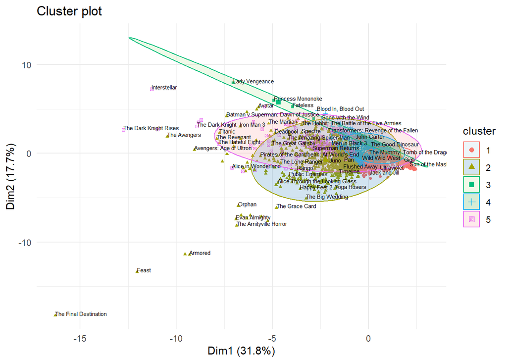

```r
fviz_cluster(fit, data = dataframe, geom = c("point"),ellipse.type = 'norm', pointsize=1)+
  theme_minimal()+geom_text(label=titles,hjust=0, vjust=0,size=2,check_overlap = T)+scale_fill_brewer(palette="Paired")
```

Silhouette plot

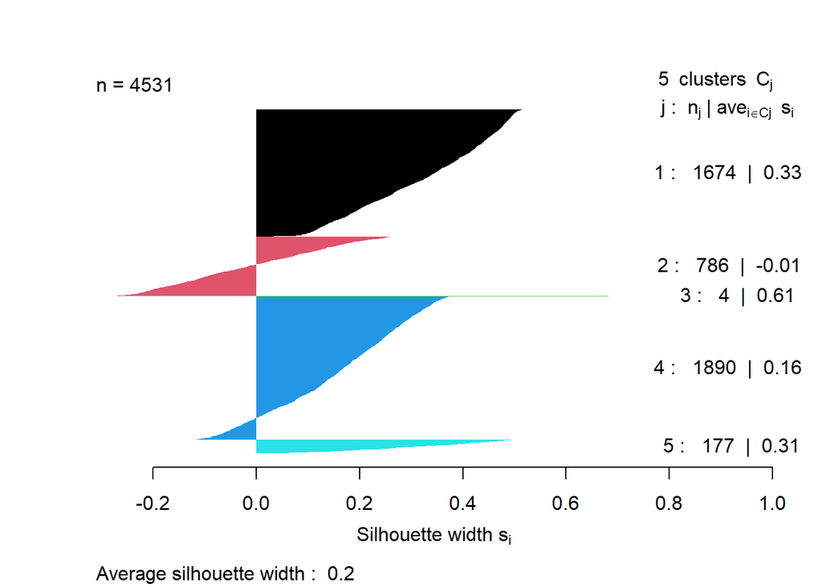

```r
d <- dist(dataframe, method="euclidean")
sil = silhouette(groups, d)
plot(sil, col=1:5, main="", border=NA)
```

This plot allows to see if the data matches the cluster well based on the distance of data points to their clusters.

In this case, clusters 1, 3 and 5 are wide so they seem to be good, whereas 2 and 4 are less wide.

**Mahalanobis distance**

As kmeans uses the Euclidean distance, correlations between variables are not taken into account. For that reason, Mahalanobis distance can be used so this correlations are taken into account. However, it uses the same shape and orientations for the whole data.

First, let’s apply this method and compute the centers and groups.

- Compute and interpret clusters

```r
S_x <- cov(dataframe)
iS <- solve(S_x)
e <- eigen(iS)
V <- e$vectors
B <- V %*% diag(sqrt(e$values)) %*% t(V)
Xtil <- scale(dataframe,scale = FALSE)
dataframeS <- Xtil %*% B

fit.mahalanobis = kmeans(dataframeS, centers=3, nstart=100)
groups = fit.mahalanobis$cluster
centers=fit.mahalanobis$centers
colnames(centers)=colnames(dataframe)
centers
```

```
##   data.gross data.duration data.director_facebook_likes
## 1  0.2310933    0.25834341                    4.7779455
## 2  0.4112318   -0.15769091                   -0.1434362
## 3 -0.2891150    0.08737962                   -0.2280156
##   data.actor_1_facebook_likes data.cast_total_facebook_likes data.budget
## 1                 0.267660031                     0.18640677 -0.01517142
## 2                -0.040002733                    -0.10251215  0.14771259
## 3                 0.008485249                     0.05555435 -0.09720338
##   data.imdb_score data.movie_facebook_likes
## 1       0.3135978                0.16435728
## 2      -0.8661801                0.03279061
## 3       0.5547918               -0.03293083
```

Once we have them we can see everything graphically.

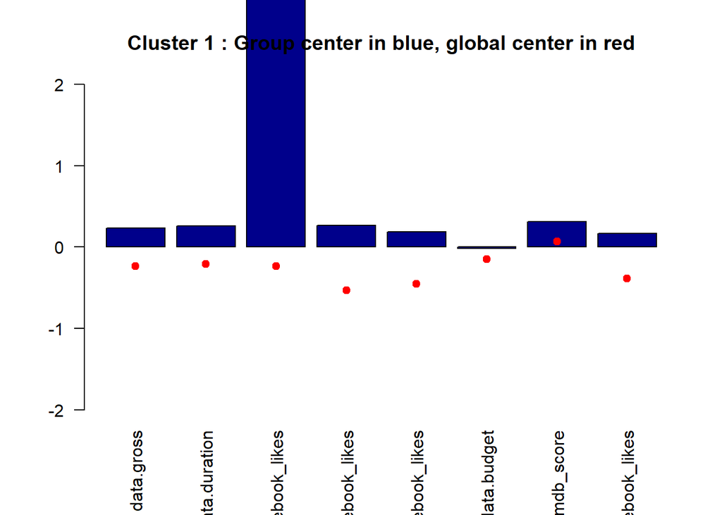

```r
i=1  # plotting the centers in cluster 1
bar1=barplot(centers[i,], las=2, col="darkblue", ylim=c(-2,2), main=paste("Cluster", i,": Group center in blue, global center in red"))
points(bar1,y=apply(dataframe, 2, quantile, 0.50),col="red",pch=19)
```

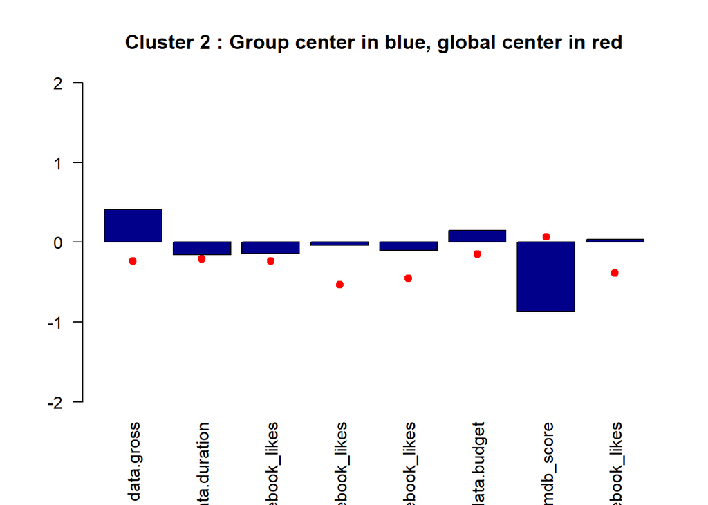

```r
i=2  # plotting the centers in cluster 1
bar1=barplot(centers[i,], las=2, col="darkblue", ylim=c(-2,2), main=paste("Cluster", i,": Group center in blue, global center in red"))
points(bar1,y=apply(dataframe, 2, quantile, 0.50),col="red",pch=19)
```

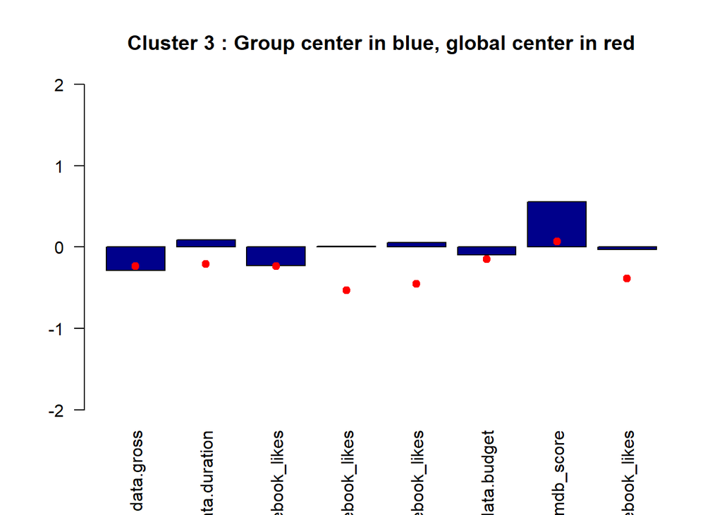

```r
i=3  # plotting the centers in cluster 1
bar1=barplot(centers[i,], las=2, col="darkblue", ylim=c(-2,2), main=paste("Cluster", i,": Group center in blue, global center in red"))
points(bar1,y=apply(dataframe, 2, quantile, 0.50),col="red",pch=19)
```

Clusters 2 and 3 are very similar. Their main differences are the gross, which is positive on cluster 2 meanwhile it is negative on cluster 3, and the IMDb score, being negative on cluster 2 and positive on cluster 3. The other variables also have differences but are less notable.

- Compute the plot

Let’s compute the clusplot.

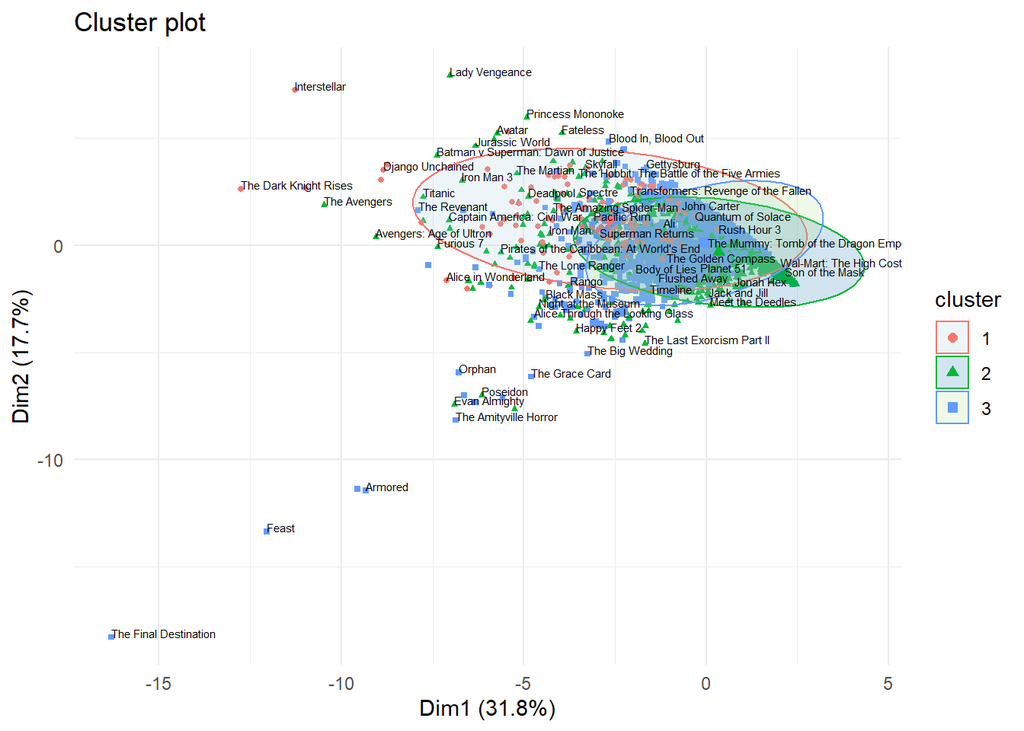

```r
fviz_cluster(fit.mahalanobis, data = dataframe, geom = c("point"),ellipse.type = 'norm', pointsize=1)+
  theme_minimal()+geom_text(label=titles,hjust=0, vjust=0,size=2,check_overlap = T)+scale_fill_brewer(palette="Paired")
```

- Analyse similarity of clusters

```r
adjustedRandIndex(fit$cluster,
                  fit.mahalanobis$cluster)
```

```
## [1] 0.3323937
```

This coefficient gives a result of 0,33 which means that are somehow similar but not much.

**Kernel k-means**

Kernel k-means mission is to capture clusters that are not linearly separable in input space.

- Compute and interpret clusters

Let’s compute it with five clusters.

```r
fit.ker <- kkmeans(as.matrix(dataframe), centers=5, kernel="rbfdot")
```

```
## Using automatic sigma estimation (sigest) for RBF or laplace kernel
```

```r
centers(fit.ker)
```

```
##            [,1]        [,2]       [,3]       [,4]       [,5]        [,6]
## [1,] -0.3993206 -0.01422644 -0.1984828 -0.5326541 -0.5244436 -0.19844639
## [2,] -0.3201406 -0.53763292 -0.2232573 -0.5142444 -0.4785089 -0.15117232
## [3,] -0.3787433 -0.79165112 -0.2178465 -0.5291810 -0.5180639 -0.22218494
## [4,]  0.7146266  0.61942530  0.4468208  0.4503070  0.4875995  0.31966467
## [5,] -0.2177050 -0.09824086 -0.1949829  0.7533637  0.6286369 -0.02939123
##             [,7]       [,8]
## [1,]  0.54926559 -0.2846018
## [2,] -1.19216084 -0.3459740
## [3,] -0.07545259 -0.2819794
## [4,]  0.25217374  0.5982837
## [5,]  0.04308239 -0.1922697
```

```r
size(fit.ker)
```

```
## [1] 1067  793  469 1434  768
```

```r
withinss(fit.ker)
```

```
## [1]  2656.6652  1708.0656   641.7281 25889.0728  2980.7661
```

Taking into account the values of the centers, some conclusions about the clusters can be drawn.

- Compute the plot

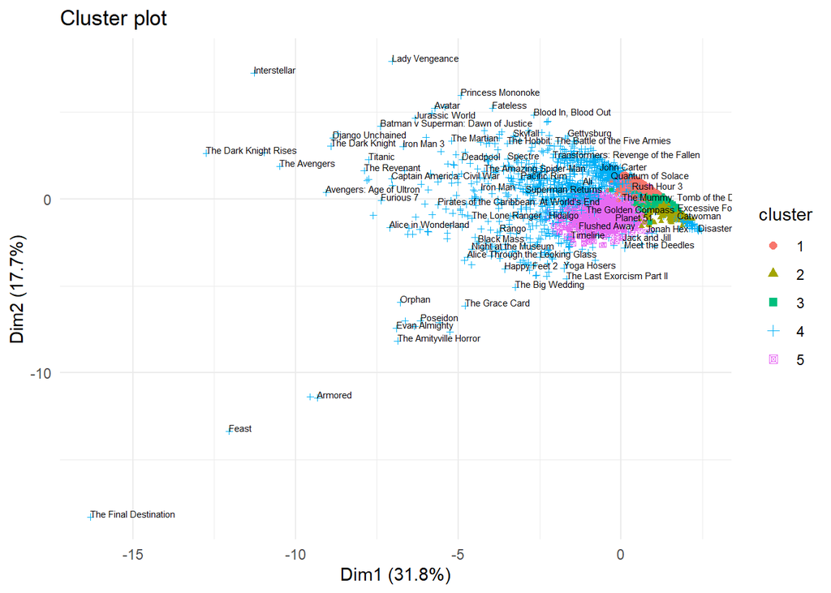

```r
object.ker = list(data = dataframe, cluster = fit.ker@.Data)
fviz_cluster(object.ker, geom = c("point"), ellipse=F,pointsize=1)+
  theme_minimal()+geom_text(label=titles, hjust=0, vjust=0,size=2,check_overlap = T)+scale_fill_brewer(palette="Paired")
```

The cluster plot, as expected, has the best movies in cluster 4, and clusters 1, 2 and 3 have similar values, which are not good ones.

**EM clustering**

EM clustering performs clustering using the Expectation Maximization algorithm.

This algorithm is based on probabilities of the data belonging to each cluster, and maximizing this value, the final clusters are obtained.

- Computing and analyzing the clusters

The clusters are created and its groups analysed.

```r
res.Mclust <- Mclust(scale(dataframe))
summary(res.Mclust)
```

```
## ----------------------------------------------------
## Gaussian finite mixture model fitted by EM algorithm
## ----------------------------------------------------
##
## Mclust VVV (ellipsoidal, varying volume, shape, and orientation) model with 7
## components:
##
##  log-likelihood    n  df       BIC       ICL
##       -4378.275 4531 314 -11400.02 -11968.99
##
## Clustering table:
##    1    2    3    4    5    6    7
##  287  432  727 1145  392  854  694
```

7 clusters have been created. The largest is number 4 with 1145 observations, and the smallest number 1, with 287.

In this method, the number of groups is automatically done, so there is no need to study previously how many groups are going to be created. However, a graph where the number of clusters can be seen visually is going to be computed.

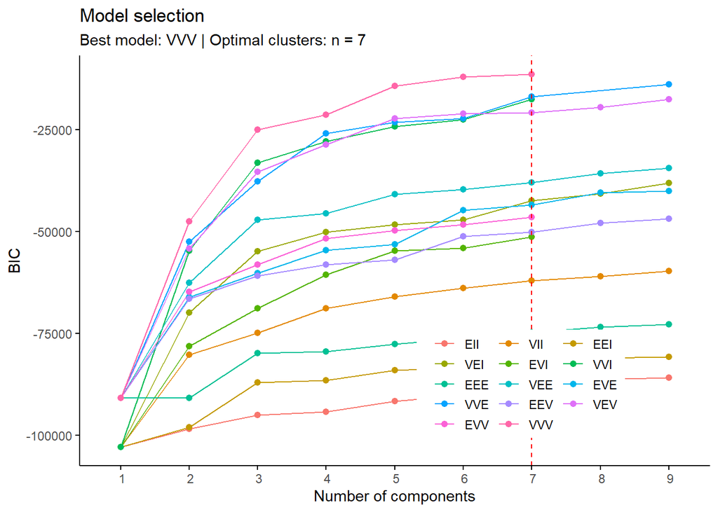

```r
fviz_mclust(object = res.Mclust, what = "BIC", pallete = "jco") +
  scale_x_discrete(limits = c(1:10))
```

In this graph it can be seen that 7 groups is the optimal number.

```r
head(res.Mclust$z)
```

```
##            [,1]          [,2]         [,3] [,4]          [,5]         [,6] [,7]
## [1,] 0.99998784 2.219366e-123 0.000000e+00    0  0.000000e+00 1.216163e-05    0
## [2,] 0.99990194  0.000000e+00 1.118169e-14    0  0.000000e+00 9.805504e-05    0
## [3,] 0.07840203 4.740837e-199 0.000000e+00    0  0.000000e+00 9.215980e-01    0
## [4,] 1.00000000  0.000000e+00 0.000000e+00    0  0.000000e+00 0.000000e+00    0
## [5,] 0.97022979  1.262226e-33 0.000000e+00    0  0.000000e+00 2.977021e-02    0
## [6,] 0.27244518  0.000000e+00 6.723195e-37    0 3.720193e-187 7.275548e-01    0
```

```r
head(res.Mclust$classification)
```

```
## [1] 1 1 6 1 1 6
```

This heads can be seen to understand how the clusters were made. The z component saves the probabilities this method is based in. The classification is where the data is assigned to a group.

- Compute the plot

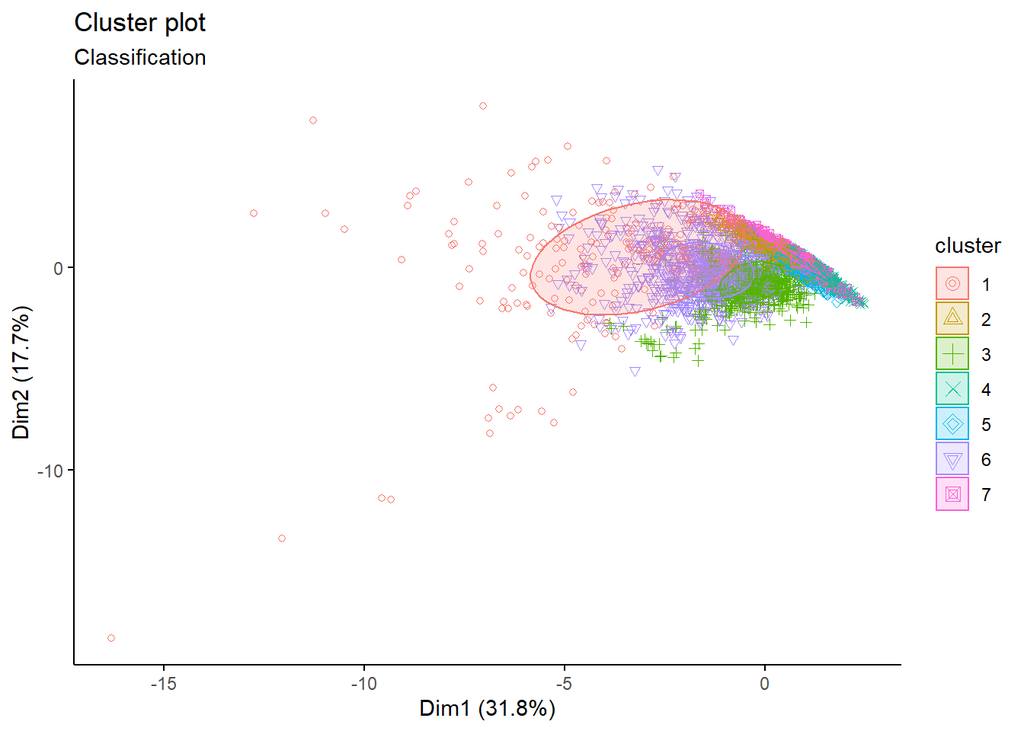

```r
fviz_mclust(object = res.Mclust, what = "classification", geom = "point",
            pallete = "jco")
```

From the plot some conclusions can be drawn. Clusters 2, 4, 5 and 7 are almost identical and group not successful films. After, clusters 3 and 6 represent better movies but with no big values. Finally, cluster 1 represents the most successful films.

**PAM**

The PAM technique is similar to kmeans but, instead of creating a fictitious film to represent the group, it takes an already existent one.

Let’s create a graph with 5 clusters.

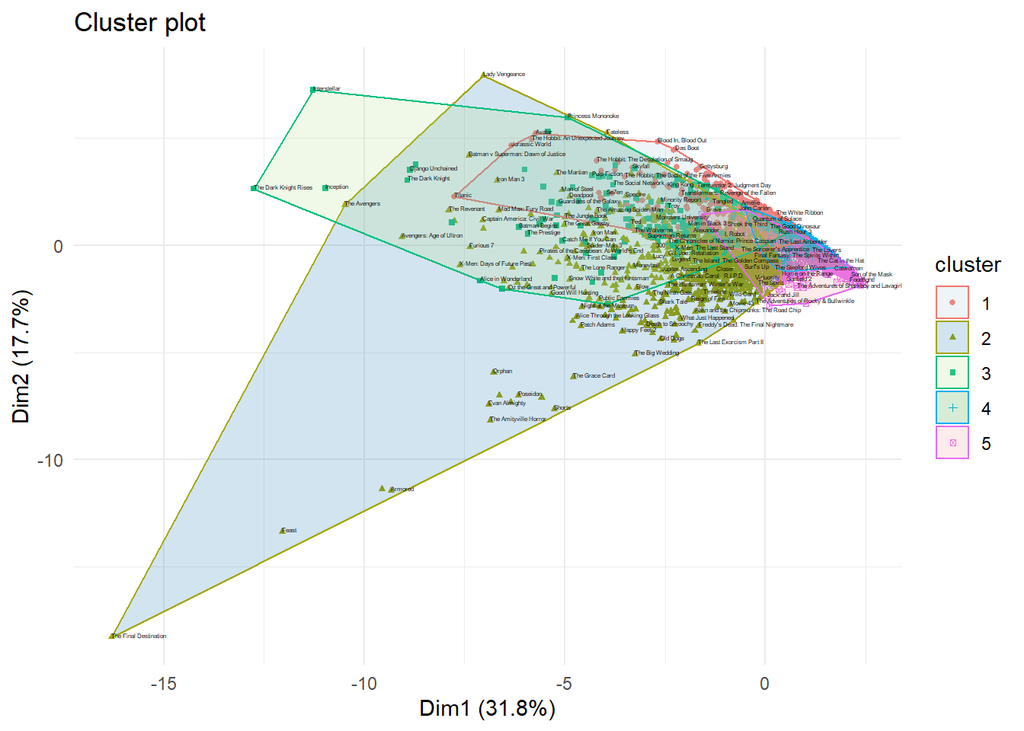

```r
fit.pam <- eclust(dataframe, "pam", stand=TRUE, k=5, graph=F)

fviz_cluster(fit.pam, data = dataframe, geom = c("point"), pointsize=1)+
  theme_minimal()+geom_text(label=titles,hjust=0, vjust=0,size=1,check_overlap = T)+scale_fill_brewer(palette="Paired")
```

**Hierarchical clustering**

Hierarchical clustering begins by treating each row as a cluster and then grouping them in a hierarchical way.

The code I used to create it is the following one:

```r
# Create clusters

#d = dist(scale(dataframe), method = "euclidean")
#hc <- hclust(d, method = "ward.D2")

# Graph

#fviz_dend(x = hc,
#         k = 5,
#         color_labels_by_k = TRUE,
#          cex = 0.8,
#       type = "phylogenic",
#        repel = TRUE)+  labs(title="Socio-economic-health tree clustering of the world") + theme(axis.text.x=element_blank(),axis.text.y=element_blank())
```

*It is with comments because it takes a really long time to process and, after doing it, I realized that this model is not very useful for the dataset I am using, as the result it gave have mixed colors and not well defined groups as it should.

# Conclusion

As a general insight of all the techniques and questions several conclusions have been reached.

It was concluded that 4 variables were enough to reach a 75% of the variability of the dataset, that is, with 4 variables we can reach the same conclusions.

About the importance of the variables, it is clear that social media is crucial and is the factor that represents the best the success of a film. After that, the gross and, finally, the IMDb score. On top of that, it was concluded that the cast of a film really makes a difference, as the main actor and the cast likes are one of the most important factors. However, the directors are not that principal.

With this information, we were also able to compute the best films, actors and directors which coincided in both the unsupervised techniques and the graphs created in the beggining as hypothesis.